# 14 Testing Hypothesis 2: ANOVA and Linear Regression

### 14.0.1 ANOVA (analysis of variance)

I wanted to add some variety to our data, so I found another [table](https://elenary.github.io/StatsForDA/R_analysis.html#https://github.com/elenary/StatsForDA/blob/main/Chapter2OnlineData2019.xls?raw=true) related to the World Happiness Report, you can read more about it [here](https://elenary.github.io/StatsForDA/R_analysis.html#https://s3.amazonaws.com/happiness-report/2019/WHR19_Ch2A_Appendix1.pdf) (by the way, this doc, apparently, is also formatted in R).

This is roughly what preprocessing of real (not the cleanest and crooked) data might look like: I combine two tables (the table for 2016 and the new table for 2019) using the function `right_join`(this means that I attach the left table to the right one, and everything that is left in the left one that does not fit into the right one is not taken) from the family `join`, rename columns and replace spaces on them with underscores using the function `rename_with`, select only the columns that interest me using the function `select`, create new variables that we have already created earlier in homework, using the mutate function and save the result in a new table in the dataset`whr_tests_hw`

```r
whr_2019 <- readxl::read_xls("Chapter2OnlineData2019.xls")
whr <- read_csv("2016.csv")

whr_2019 %>%
  rename_with(~ gsub(" ", "_", .), .cols = everything()) %>%
  select(Country_name:Negative_affect) %>%
  filter(Year <= 2016) -> whr_2019

whr %>%
  rename_with(~ gsub(" ", "_", .), .cols = everything()) %>%
  select(Country, Happiness_Rank, Happiness_Score) %>%
  right_join(whr_2019, by = join_by(Country == Country_name), multiple = "last") -> tmp

whr %>%
  select(Country:Region) %>%
  right_join(tmp, by = join_by(Country == Country), multiple = "all") %>%
  mutate("top20" = ifelse(Happiness_Rank<=20, "hehe", "not hehe"),
         "mean_position" = ifelse(Happiness_Score>= mean(Happiness_Score, na.rm = TRUE), "upper", "lower")) -> whr_tests_hw
```

Previously, we tested the hypothesis that the Happiness Score differs in two regions: Western and Eastern and Central Europe. But what if I want to check whether the level of happiness differs statistically significantly in three regions - Western and Eastern and Central Europe and in Latin America? Again, we turn to [the statistical criteria](https://elenary.github.io/StatsForDA/stats_criteria.html#stats_criteria) we studied last semester , remember the picture with the tree of choosing statistical tests https://miro.com/app/board/uXjVOxmKhr8=/ . If we have a quantitative PP, categorical NP / categorical, and we need to conduct 3 or more comparisons - then we move from the t-test to [ANOVA (analysis of variance)](https://elenary.github.io/StatsForDA/stats_criteria_ttest_anova.html#anova) .

I will periodically adhere to the form of writing code when I do everything at once inside one pipe - both filtering and plotting graphs or calculating a test, but do not forget that before writing everything together, you need to make sure that each line works. And it may be more convenient at first to create more variables and write the filtering results there, and then use this variable - this will make it easier to debug the code. For example, you can first filter the data and write it to a new dataset (sometimes it happens that you cannot do without this form of writing)

```
whr_tests_hw %>%
  filter(Region == "Central and Eastern Europe" | Region == "Western Europe" | Region == "Latin America and Caribbean") %>%
  filter(Year == "2016") -> whr_anova
```

Recalling the assumptions for ANOVA

First, wages should be distributed close to a normal distribution.

```
whr_anova %>%
  ggplot(aes(x = Happiness_Score)) +
  geom_density(color = "#355C7D") +
  theme_minimal()
```

```
whr_anova %>%
  ggplot(aes(sample = Happiness_Score)) +
  stat_qq(color = "#355C7D") +
  geom_qq_line() +
  theme_minimal()
```

The second assumption is homogeneity (homoscedasticity) of variances. Variances should be the same in our groups. If they are different, this is bad, and we will have to use nonparametric analogs of ANOVA. Homogeneity of variances is checked using Levene’s Test. Note: here we are interested in obtaining a NON-significant result - because if the test yielded a significant result, then the variances in the groups are different, and this is not ok. We will need a function `leveneTest`from the package`car`

```
options(scipen = 999) #

# install.packages("car")
library(car)
leveneTest(Happiness_Score ~ Region, data = whr_anova)
```

```
aov_model1 <- aov(Happiness_Score ~ Region, data = whr_anova) #выполняем АНОВУ
summary(aov_model1) #output for ANOVA results
```

How to interpret these results? The first thing we look at is the p-value (column Pr(F)). If it is less than the set levelaa, then we say that *we reject the null hypothesis and we have obtained statistically significant differences* . If the p-value is greater than or equal toaa– *we do not have enough evidence to support the alternative hypothesis, and we say that we do not reject the null hypothesis* .

We can calculate it separately for the previous table using the package function effectsize

```
# install.packages("effectsize")
library(effectsize)

eta_squared(aov_model1)
```

Visualize the results. The most common methods for visualizing ANOVA are boxplots or violet plots.

```
whr_anova %>%
  ggplot(aes(x=Region, y = Happiness_Score, fill = Region)) +
  geom_boxplot() +
  theme_minimal() +
  scale_fill_manual(values = wes_palette("FantasticFox1"))
```

```
whr_anova %>%
  ggplot(aes(x=Region, y = Happiness_Score, color = Region, group = 1)) +
  stat_summary(fun = mean, geom = 'point') +
  stat_summary(fun = mean, geom = 'line') +
  stat_summary(fun.data = mean_cl_boot, geom = 'errorbar') +
  theme_minimal() +
  scale_color_manual(values = wes_palette("FantasticFox1"))
```

#### 14.0.1.1 Post-hoc analysis

Post hocs are pairwise multiple comparisons of everything with everything. Remember that when we do this, we risk getting a statistically significant result purely by chance, because the probability of a type I error increases greatly, and corrections for multiple comparisons are needed. You can do post hoc analysis, for example, using built-in functions `TukeyHSD`or`pairwise.t.test`

```
TukeyHSD(aov_model1, conf.level=.95)
```

```
pairwise.t.test(whr_anova$Happiness_Score, whr_anova$Region, p.adj = "bonf")
```

#### 14.0.1.2 Nonparametric Analogues of ANOVA

If our variable has significant outliers, fails the normality test, and the variances in the groups are statistically significantly different, then we cannot use ANOVA. What to do? Conduct an analogue of ANOVA, the Kruskal-Wallis test. I will show it on the same data that we took for ANOVA, where we looked at different levels of happiness by region.

```
kruskal.test(Happiness_Score ~ Region, data = whr_anova)
```

#### 14.0.1.3 Multivariate ANOVA

We tested the hypothesis with only one NP - region. But what if my hypothesis concerns several factors? For example, I want to test the hypothesis that the variable `Life_Ladder`(analogous to `Happiness Score`, shows the survey results, where respondents are by level of happiness in the form of a ladder with 10 steps) is affected by both region and year.

I’ll go back to the original dataset and remove the year filtering.

It’s all the same - let’s check the assumptions first.

```
whr_tests_hw %>%
  filter(Region == "Central and Eastern Europe" |
           Region == "Western Europe" |
           Region == "Latin America and Caribbean") %>%
  ggplot(aes(x = Life_Ladder)) +
  geom_density(color = "#355C7D") +
  theme_minimal()
```

```
whr_tests_hw %>%
  filter(Region == "Central and Eastern Europe" |
           Region == "Western Europe" |
           Region == "Latin America and Caribbean") %>%
  ggplot(aes(sample = Life_Ladder)) +
  stat_qq(color = "#355C7D") +
  geom_qq_line() +
  theme_minimal()
```

```
whr_tests_hw %>%
  filter(Region == "Central and Eastern Europe" |
           Region == "Western Europe" |
           Region == "Latin America and Caribbean") %>%
  aov(Life_Ladder ~ Region + as.factor(Year), data = .) -> aov_model3
# as.factor() converts quantitative variable intpo categorical
summary(aov_model3)
```

The formula of the entry `dependent var ~ independen var 1 + independent var 2` means that I take into account two factors independently of each other. But sometimes I am interested in the interaction of factors: maybe in some regions nothing has changed much over the years, the level of happiness measured as `Life_Ladder`was constant, and in some regions there was a huge increase (or a huge negative increase) in the level of happiness? Then I will need to check the interaction of factors, and the formula will be: `dependent var ~ independen var 1 * independent var 2` Wherever I am interested in interaction, I put an asterisk instead of a plus.

```
whr_tests_hw %>%
  filter(Region == "Central and Eastern Europe" |
           Region == "Western Europe" |
           Region == "Latin America and Caribbean") %>%
  aov(Life_Ladder ~ Region * as.factor(Year), data = .) -> aov_model4
summary(aov_model4)
```

Next, to determine what exactly was significant, we do post-hocs.

```
TukeyHSD(aov_model3, conf.level=.95)
TukeyHSD(aov_model4, conf.level=.95)
```

I won’t draw a table – it turns out to be monstrous because we took the years, and they start from 2005: imagine how many pairwise comparisons there are…

#### 14.0.1.4 Repeated Measures ANOVA

Actually, the year variable is a within-group factor. And to be honest, it is not very good to take it into account in the same way as the Region factor, otherwise we will lose a lot of information. In R, ANOVA with repeated measures can be done by specifying additional parameters in the aov() function, or with the already familiar ezANOVA() function, or with the very similar anova_test() function.

```
whr_tests_hw %>%
  filter(Region == "Central and Eastern Europe" |
           Region == "Western Europe" |
           Region == "Latin America and Caribbean") %>%
  filter(Year > 2010) %>% #возьму года после 2010, чтобы было поменьше
  drop_na(Life_Ladder, Year) %>% #удаляю пропущенные значения в интересующих меня колонках
  aov(Life_Ladder ~ Year + Error(Country/Year), .) %>%
  summary()
```

How to set this formula: If a factor appears several times for the same subject or country in this case, then the formula for writing it will be as follows `dependent var ~ independen var + Error(ID/independen var)`

The anova_test function has a more human syntax, but it is very sensitive to data, and for example, it was not built on these data. *Later I realized why: I forgot to check for the identity of the variances, so the model does not converge! But I am too lazy to rewrite it.*

```
whr_tests_hw %>%
  filter(Region == "Central and Eastern Europe" |
           Region == "Western Europe" |
           Region == "Latin America and Caribbean") %>%
  filter(Year > 2010) %>%
  drop_na(Life_Ladder, Year) %>%
  ezANOVA(., dv = Life_Ladder, wid = Country, within = as.factor(Year))
```

### 14.0.2 Reshaping

Sometimes, for repeated measures tests, some functions accept data in a different format as input. For example, this is exactly what happened in Jamovi. Notice how our repeated measures data looks now: we have a column `Year`that lists the years, and a column `Life_Ladder`that lists the values corresponding to those years.

```
whr_tests_hw %>%
  select(Country, Year, Life_Ladder) %>%
  filter(Year>2010) %>%
  head() #head of the table, first 10 rows
```

This data format is called *long* (no joke, that’s what it’s called!) because the data is stretched out in length, instead of each row consisting of unique data (pay attention to the column `Country`- there are repeating values there, because we have many measurements in different years for each country). Sometimes it is necessary to convert the data to *a wide* format - so that the values in the rows do not repeat, but instead of two columns, we have a column with measurements `Life_Ladder`for each year. This transformation is called data reshaping, as if changing their shape. You can convert the data type from long to wide format or back using the pivot_wider pivot_longer functions. Unfortunately, reshaping is not implemented in Jamovi.

```
whr_tests_hw %>%
  select(Country, Year, Life_Ladder) %>%
  filter(Year>2010) %>%
  pivot_wider(names_from = Year, values_from = Life_Ladder) %>%
  head()
```

## 14.1 Assignments after the seminar 6

Test several hypotheses on the dataset `whr_tests_hw`using ANOVA and linear regression analysis: select variables suitable for these tests, formulate a hypothesis, formulate $H_0$ and $H_1$, select levelaa, (if necessary, preprocess the data), check the assumptions for the tests.

1. Select appropriate variables, formulate a meaningful hypothesis, and test it using one-way ANOVA. Interpret the results: was the hypothesis confirmed?
2. Select appropriate variables, formulate a meaningful hypothesis and test it with a multivariate ANOVA. Interpret the results: was the hypothesis confirmed?
3. Select appropriate variables, formulate a meaningful hypothesis, and test it using repeated measures ANOVA. Interpret the results: was the hypothesis supported?
4. Conduct the same tests of hypotheses 1-3 using linear regression analysis.

## 14.2 Linear Regression Analysis

Now let’s move on to one of the most important methods in data analysis, including psychological ones - [linear regression](https://elenary.github.io/StatsForDA/stats_criteria_linear.html#linreg) . First of all, we need to remember when this method is used - and it is used when both the PP and the NP are quantitative. When we talked about correlations, we discussed that this is a simplified version of linear regression, when we have only one NP. For one NP, we can do both a correlation test and a regression analysis, but when there are two or more quantitative NPs, we only need regression. We also discussed that ANOVA is actually a subtype of linear regression, if we move from quantitative NPs to categorical ones! But first things first, let’s start with quantitative NPs, a more classic case of linear regression.

Before we build a regression model, we need to check [the assumptions for linear regression](https://elenary.github.io/StatsForDA/stats_criteria_linear.html#assumptions_linreg)

Note that we are not so interested in how normally the salaries are distributed! This is the power of linear regression, that it is robust to salaries of different distributions. But another assumption regarding the distribution of data by salaries is the linearity between the NP and the salaries on which we want to build the model, we need to make sure that there is a linear relationship between them (and not a hole in a donut or a gnome-shaped entity). This is the first assumption.

I chose for analysis the hypothesis that the level of happiness according to the subjective position on the ladder `Life_Ladder`depends on the parameters `Log_GDP_per_capita`(purchasing power, GDP per capita), `Social_support`, `Freedom_to_make_life_choices`,`Perceptions_of_corruption.`

Let’s test the assumption of a linear relationship between Life_Ladder salary and several potential variables that I have selected for analysis.

```
whr_tests_hw %>%
  ggplot(aes(x = Log_GDP_per_capita, y = Life_Ladder)) +
  geom_point(color = "#355C7D", size = 1) +
  theme_minimal()
```

```
whr_tests_hw %>%
  ggplot(aes(x = Social_support, y = Life_Ladder)) +
  geom_point(color = "#355C7D", size = 1) +
  theme_minimal()
```

```
whr_tests_hw %>%
  ggplot(aes(x = Freedom_to_make_life_choices, y = Life_Ladder)) +
  geom_point(color = "#355C7D", size = 1) +
  theme_minimal()
```

```
whr_tests_hw %>%
  ggplot(aes(x = Perceptions_of_corruption, y = Life_Ladder)) +
  geom_point(color = "#355C7D", size = 1) +
  theme_minimal()
```

### 14.2.1 Linear Regression with One Predictor (Factor)

I will build a model with one factor to begin with – Log_GDP_per_capita. The model is built using the lm() function, to display the main information about the model you need to display summary(). By the way, you can also display these results immediately as ANOVA – this is all because, in fact, this is a subspecies of the same linear regression, and if we like the ANOVA table, we can get it by simply applying the functions to the anova() model

```
whr_tests_hw %>%
  lm(Life_Ladder ~ Log_GDP_per_capita, .) -> lm_model1
```

```
summary(lm_model1)
```

```
anova(lm_model1)
```

In general, we can already begin to interpret the results of the model, but it is still too early - first we need to make sure that the variances of the residuals are equal, that is, that the assumption of *homoscedasticity* (homogeneity) of the variances is met. This is easiest to check by displaying the first of four graphs that are displayed if you pass the linear model to the basic plot() function.

```
plot(lm_model1, 1)
```

We can make the graph prettier using ggplot(). To do this, we will use the fact that the result of executing lm() is a list containing many different data, including both the model residuals and the predicted values separately.

```
head(lm_model1$residuals)
```

```
head(lm_model1$fitted.values)
```

```
ggplot(lm_model1, aes(x = lm_model1$fitted.values, y = lm_model1$residuals)) +
  geom_point(color = "#355C7D", size = 1) +
  theme_minimal()
```

Now let’s take an anti-example and see what happens to the distribution of the residuals.

```
whr_tests_hw %>%
  lm(Life_Ladder ~ Perceptions_of_corruption, .) -> lm_model2_anti
plot(lm_model2_anti, 1)
```

The next assumption is that the residuals must be normally distributed. Yes, we do not check for normality of the PP distribution, but the residuals need to be checked - otherwise we will not be able to draw a line with the least squares method calculation, that is, trying to get closer to all our points at once. Let’s check this assumption by displaying the second graph of the standard plot() function.

```
plot(lm_model1, 2)
```

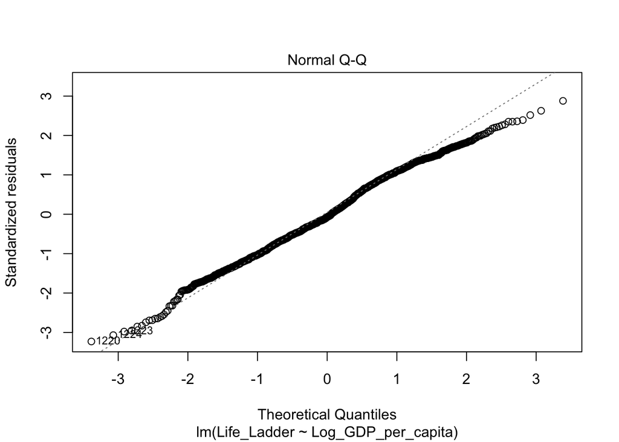

Or, as we have already built beautiful graphs to check normality using ggplot

```
ggplot(data = lm_model1, aes(x = lm_model1$residuals)) +
  geom_density(color = "#355C7D") +
  theme_minimal()
```

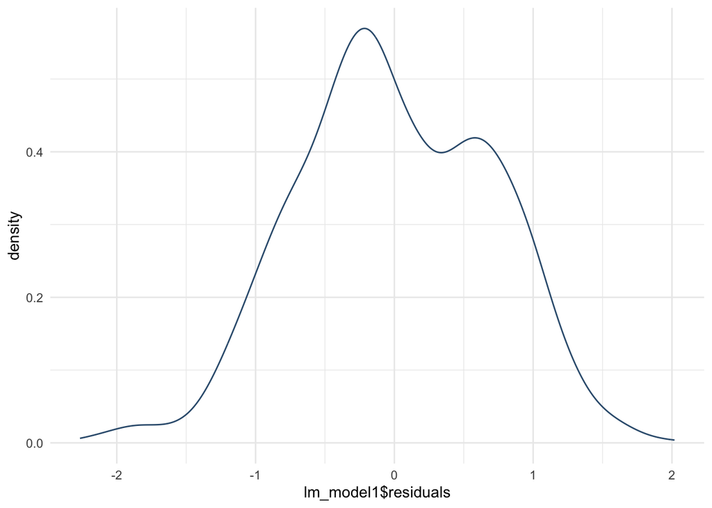

```
ggplot(data = lm_model1, aes(sample = lm_model1$residuals)) +
  stat_qq(color = "#355C7D") +
  geom_qq_line() +
  theme_minimal()
```

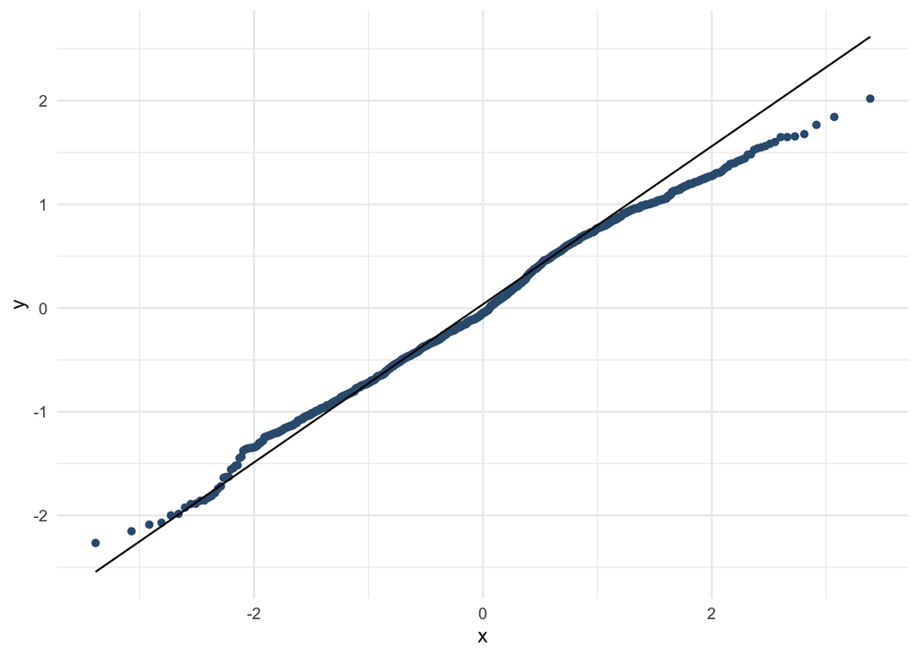

So, we have met all the assumptions for the single predictor model! We only have the assumption of no multicollinearity left, but it is not applicable to the single predictor model.

```
lm_model1
```

```
##
## Call:
## lm(formula = Life_Ladder ~ Log_GDP_per_capita, data = .)
##
## Coefficients:
##        (Intercept)  Log_GDP_per_capita
##            -1.4066              0.7421
```

```
summary(lm_model1)
```

```
##
## Call:
## lm(formula = Life_Ladder ~ Log_GDP_per_capita, data = .)
##
## Residuals:
##      Min       1Q   Median       3Q      Max
## -2.26515 -0.47805 -0.04913  0.54993  2.01866
##
## Coefficients:
##                    Estimate Std. Error t value            Pr(>|t|)
## (Intercept)         -1.4066     0.1467  -9.587 <0.0000000000000002 ***
## Log_GDP_per_capita   0.7421     0.0158  46.973 <0.0000000000000002 ***
## ---
## Signif. codes:  0 '***' 0.001 '**' 0.01 '*' 0.05 '.' 0.1 ' ' 1
##
## Residual standard error: 0.7016 on 1404 degrees of freedom
##   (15 observations deleted due to missingness)
## Multiple R-squared:  0.6111, Adjusted R-squared:  0.6109
## F-statistic:  2206 on 1 and 1404 DF,  p-value: < 0.00000000000000022
```

What is it equal to?R2R2? It is equal to 0.61, which is a very good result. That is, 61% of the variability of our data at the Life_Ladder level is determined by the level of purchasing power Log_GDP_per_capita!

I can now write the equation of the regression line as follows:

$\hat Life\_Ladder = -1.4 + 0.74 \times Log\_GDP\_per\_capita$

Let’s now visualize our regression line

```
whr_tests_hw %>%
  ggplot(aes(x = Log_GDP_per_capita, y = Life_Ladder)) +
  geom_point(color = "#355C7D", size = 1, alpha = 0.5) +
  geom_smooth(method = 'lm', color = "violet") +
  theme_minimal()
```

### 14.2.2 Linear Regression with Multiple Predictors (Factors)

Everything is the same, but now we will take the second predictor into the model – Freedom_to_make_life_choices.

```
whr_tests_hw %>%
  lm(Life_Ladder ~ Log_GDP_per_capita + Freedom_to_make_life_choices, .) -> lm_model3_multy
lm_model3_multy
```

```
summary(lm_model3_multy)
```

Checking is allowed

```
plot(lm_model3_multy, 1)
```

```
plot(lm_model3_multy, 2)
```

Now we need to check the assumption about the absence of multicollinearity - that there is no strong correlation between the predictors (NP), otherwise our model will be a bit meaningless. We will check using the vif() function, the dispersion inflation coefficient. The indicators are quite arbitrary, but it is considered that if the values are greater than 5, then this is a very strong correlation between the variables, and the strongly correlated variable should be removed.

```
car::vif(lm_model3_multy)
```

## 14.3 Assignments after the seminar 7

1. Select variables suitable for linear regression in the data`whr_tests_hw.csv`
2. Construct a linear regression on these variables, with one factor (LF)
3. Construct a linear regression on these variables, but with at least two factors (NP)
4. Plot diagnostic plots for each model: how equal is the variance of the residuals for these models? Can we trust the results of these models?
5. Determine which model best explains the data (i.e. wage variability)?
6. Write the linear regression equation for both models.

## 14.4 Logistic Regression

Let’s move from linear regression to [logistic](https://elenary.github.io/StatsForDA/stats_criteria_categ.html#logreg) regression. First, let’s remember what this method is and when it is used - it is used when the salary is not quantitative, but categorical, and, as a rule, has two gradations. This is the most classic case of logistic regression, although the salary in it can have more gradations than two - then it will be *a multinomial logistic regression* . All machine learning is built on log regression - tasks in which it is necessary to determine whether an image belongs to a certain pattern (for example, text recognition), whether a credit borrower is reliable for issuing a loan (scoring models in banks), etc. use this method.

We will consider it on the same example of our data from the World Happiness Report. They are not very suitable for this method, so the task will be a bit artificial - we will try to predict whether a country will be in the first or second half of the rating by level of happiness (we created a special variable for this). First, I will recode this variable into 1 and 0, since log regression works with numerical values 0 and 1.

```
whr_tests_hw %>%
  mutate(mean_position_bi = ifelse(mean_position == "upper", 1, 0)) -> whr_tests_hw
```

```
table(whr_tests_hw$mean_position)
```

```
whr_tests_hw %>%
  glm(mean_position_bi ~ 1, data = ., family = binomial) -> lm_model_log1
summary(lm_model_log1)
```

```
log(75/78)
```

```
# log(p/1-p) = intercept
```

Let’s complicate the model and add GDP per capita as a predictor

```
whr_tests_hw %>%
  glm(mean_position_bi ~ Log_GDP_per_capita, ., family = binomial) -> lm_model_log2
summary(lm_model_log2)
```